# Week6

Ding Ding

October 12, 2016

## Title: Mortality in a fatality car accident is associated with different positions in the crash

## Introduction

Nation’s highways in motor vehicle traffice crashes result in 35,092 lives lost, 45,495 of injured victims, and bllions of dollars in property damage[1]. For all those injuried in crashes, four variables play key role for surviving through the accidents are location of the person in the crash, alcohol,restriction use and extrication. Location in the crash includes pedestrian,pedalcyclist, driver and occupant in different position in the vehicle. Alcohol is tested with Breathalyzer “BAC”. Extrication is if equipment or other force was used to remove this person from the vehicle.

## Methods

### Data Collection

For our analysis we used the open data set that contains detailed, anonymized information about each of these tragic incidents of 2015. Data is downloaded from NHTSA’s Fatality Analysis Reporting System (FARS) on September 9, 2016.

### Exploratory Analysis

Exploraloty analysis was performed by examining plots and tables of the recorded data. We identified all the injuried people in fatal crash are categoried into fatal and survivor, which is binary outcome for analysis. Exploratory analysis was used to (1) verify the quality of the data, (2)identify response, key varibles and potential confounders,and (3) determine the variables and regression model for the analysis.

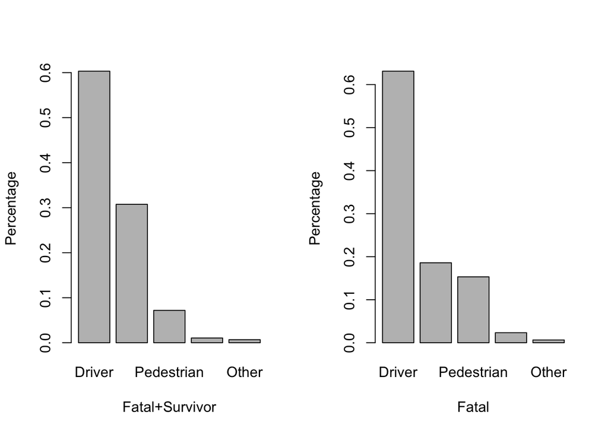

## Results

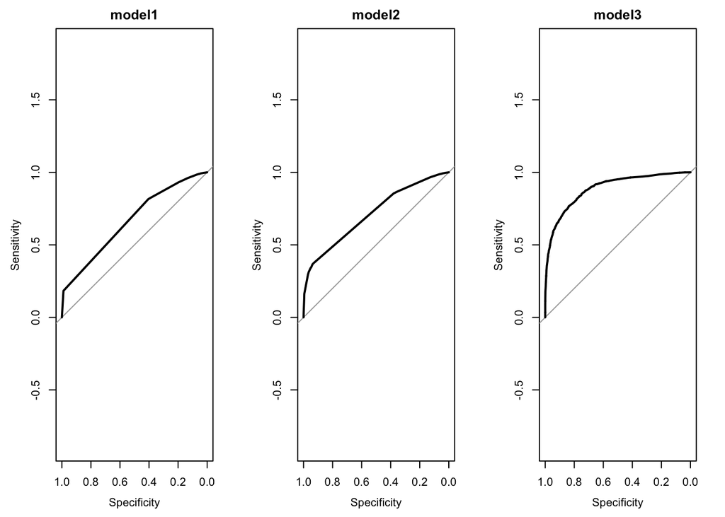